# ps5-work

Timur

2023-02-19

## 1) Load and Check Data (5pt)

### 2.

```r
library(tidyverse)
gap <- read_delim("data/gapminder.csv.bz2")
nrow(gap)
```

```
## [1] 13055
```

```r
ncol(gap)
```

```
## [1] 25
```

### 3.

```r
gap %>%
  sample_n(3) %>%
  print()
```

```
## # A tibble: 3 × 25
##   iso3  name  iso2  region sub-r…¹ inter…²  time total…³ ferti…⁴ lifeE…⁵ child…⁶
##   <chr> <chr> <chr> <chr>  <chr>   <chr>   <dbl>   <dbl>   <dbl>   <dbl>   <dbl>
## 1 YEM   Yemen YE    Asia   Wester… <NA>     2005  2.01e7    5.42    63.5    72.3
## 2 MDV   Mald… MV    Asia   Southe… <NA>     2010  3.66e5    2.21    75.9    13.9
## 3 SUR   Suri… SR    Ameri… Latin … South …  2008  5.17e5    2.66    69.9    24.3
## # … with 14 more variables: youthFemaleLiteracy <dbl>, youthMaleLiteracy <dbl>,
## #   adultLiteracy <dbl>, GDP_PC <dbl>, accessElectricity <dbl>,
## #   agriculturalLand <dbl>, agricultureTractors <dbl>, cerealProduction <dbl>,
## #   fertilizerHa <dbl>, co2 <dbl>, greenhouseGases <dbl>, co2_PC <dbl>,
## #   pm2.5_35 <dbl>, battleDeaths <dbl>, and abbreviated variable names
## #   ¹`sub-region`, ²`intermediate-region`, ³totalPopulation, ⁴fertilityRate,
## #   ⁵lifeExpectancy, ⁶childMortality
```

## 2 Descriptive Statistics (15pt)

### 1.

```r
gap %>%
  summarize(iso3names = n_distinct(iso3)) %>%
  print()
```

```
## # A tibble: 1 × 1
##   iso3names
##       <int>
## 1       253
```

```r
gap %>%
  summarize(iso2names = n_distinct(iso2)) %>%
  print()
```

```
## # A tibble: 1 × 1
##   iso2names
##       <int>
## 1       249
```

```r
gap %>%
  summarize(names = n_distinct(name)) %>%
  print()
```

```
## # A tibble: 1 × 1
##   names
##   <int>
## 1   250
```

### 2. a)

```r
gap %>%
  group_by(iso2) %>%
  summarize(names_under_iso2 = n_distinct(name)) %>%
  filter(names_under_iso2 > 1) %>%
  print()
```

```
## # A tibble: 1 × 2
##   iso2  names_under_iso2
##   <chr>            <int>
## 1 <NA>                 2
```

#### There are no countries with multiple iso-2 codes, however there are two countries without iso-2 codes, which is why N/A shows up when we filter for countries with more than one iso-2 code.

### 2. b)

```r
gap %>%
  group_by(name) %>%
  summarize(iso3_under_name = n_distinct(iso3)) %>%
  filter(iso3_under_name>1) %>%
  print()
```

```
## # A tibble: 1 × 2
##   name  iso3_under_name
##   <chr>           <int>
## 1 <NA>                4
```

#### I was a tad confused by this question, as no countries did have more than one iso3. The two hints, which were CHANISL, and NLD CURACO, did not have a value in name. The value was in iso3. So, there were four countries that did not have a name value, and they did have an iso3 value.

### 3.

```r
gap %>%
  summarize(max_year = max(time, na.rm = TRUE)) %>%
  print()
```

```
## # A tibble: 1 × 1
##   max_year
##      <dbl>
## 1     2019
```

```r
gap %>%
  summarize(min_year =min(time, na.rm = TRUE)) %>%
  print()
```

```
## # A tibble: 1 × 1
##   min_year
##      <dbl>
## 1     1960
```

## 3 CO2 Emissions (30pt)

### 1.

```r
gap %>%
  group_by(time) %>%
  summarize(num_na = sum(is.na(co2))) %>%
  arrange(desc(num_na)) %>%
  head(5)
```

```
## # A tibble: 5 × 2
##    time num_na
##   <dbl>  <int>
## 1  2017    217
## 2  2018    217
## 3  2019    217
## 4  1960     60
## 5  1961     60
```

```r
gap %>%
  group_by(time) %>%
  summarize(num_na = sum(is.na(co2_PC))) %>%
  arrange(desc(num_na)) %>%
  head(5)
```

```
## # A tibble: 5 × 2
##    time num_na
##   <dbl>  <int>
## 1  2017    217
## 2  2018    217
## 3  2019    217
## 4  1960     60
## 5  1961     60
```

### 2.

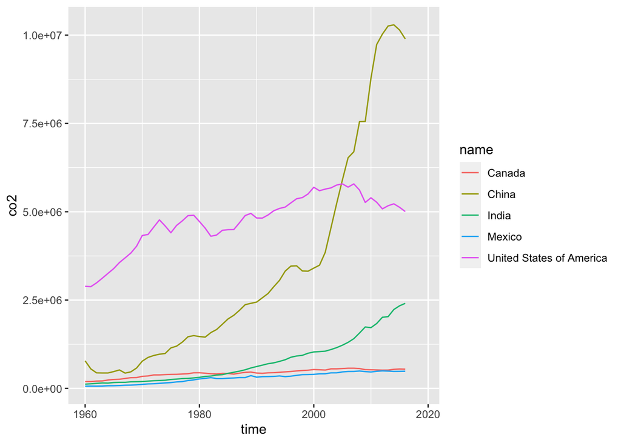

```r
countries <- c("United States of America", "India", "China", "Mexico", "Canada")
selected_countries <- gap %>%
  filter(name %in% countries) %>%
ggplot(aes(x=time, y=co2, col=name)) +
  geom_line()
print(selected_countries)
```

#### We can say that China is much higher in total CO2 emissions compared to the others, with US in second. This was not always the case, however China skyrocketed in terms of total CO2 emissions in the 2000’s, when they passed America.

### 3.

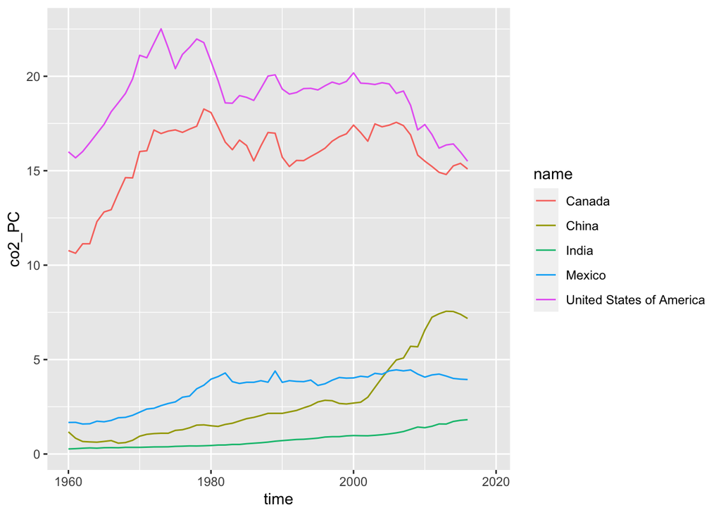

```r
countries <- c("United States of America", "India", "China", "Canada", "Mexico")
selected_countries <- gap %>%
  filter(name %in% countries) %>%
ggplot(aes(x=time, y=co2_PC, col=name)) +
  geom_line()
print(selected_countries)
```

#### This shows that per capita, China is not contributing as much CO2 compared to the US, or another developed western country in Canada.

### 4

```r
gap %>%
  group_by(region, time) %>%
  summarize(avg_region <- mean(co2_PC, na.rm = TRUE)) %>%
  ##sample_n(2) %>%
  print()
```

```
## # A tibble: 366 × 3
## # Groups:   region [6]
##    region  time `avg_region <- mean(co2_PC, na.rm = TRUE)`
##    <chr>  <dbl>                                      <dbl>
##  1 Africa  1960                                      0.291
##  2 Africa  1961                                      0.300
##  3 Africa  1962                                      0.299
##  4 Africa  1963                                      0.310
##  5 Africa  1964                                      0.349
##  6 Africa  1965                                      0.385
##  7 Africa  1966                                      0.422
##  8 Africa  1967                                      0.607
##  9 Africa  1968                                      0.781
## 10 Africa  1969                                      0.824
## # … with 356 more rows
```

#### Africa has the **lowest** CO2 emissions per capita. Furthermore Africa is mostly increasing over the time period while the other continents had their peaks **earlier**. For example, the Americas had their peak in the 70’s and are in the 2010’s are now roughly 50% of their old peak

### 5.

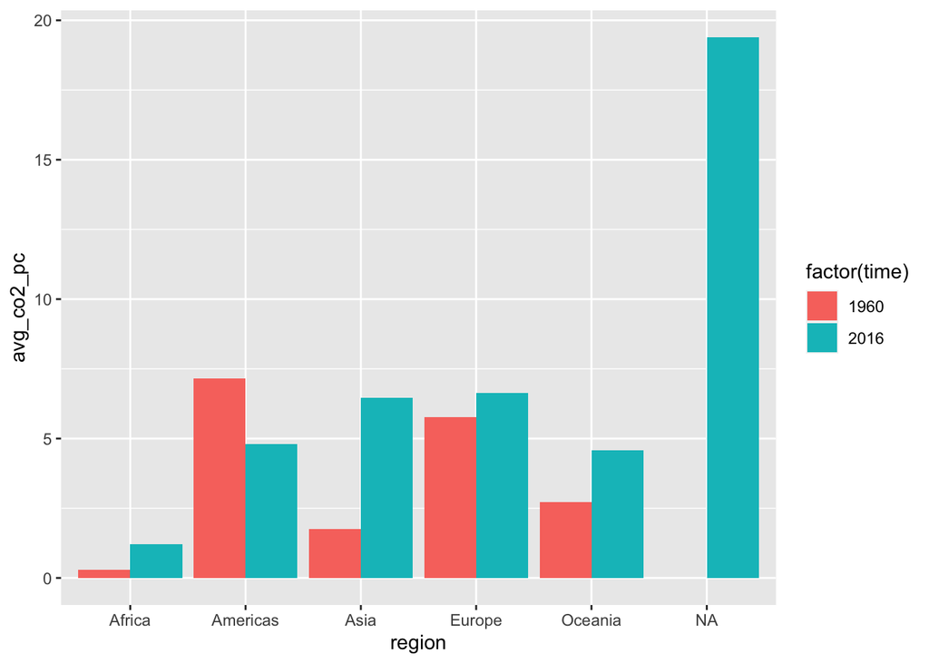

```r
gap_bars <- gap %>%
  filter(time %in% c(1960, 2016))
gap_bars %>%
  group_by(region, time) %>%
  summarize(avg_co2_pc = mean(co2_PC, na.rm= TRUE)) %>%
  ggplot(aes(x=region, y=avg_co2_pc, fill=factor(time))) +
  geom_col(position="dodge")
```

```r
print(gap_bars)
```

```
## # A tibble: 433 × 25
##    iso3  name        iso2  region  sub-r…¹ inter…²  time total…³ ferti…⁴ lifeE…⁵
##    <chr> <chr>       <chr> <chr>   <chr>   <chr>   <dbl>   <dbl>   <dbl>   <dbl>
##  1 ABW   Aruba       AW    Americ… Latin … Caribb…  1960  5.42e4    4.82    65.7
##  2 ABW   Aruba       AW    Americ… Latin … Caribb…  2016  1.05e5    1.87    75.9
##  3 AFG   Afghanistan AF    Asia    Southe… <NA>     1960  9.00e6    7.45    32.4
##  4 AFG   Afghanistan AF    Asia    Southe… <NA>     2016  3.54e7    4.8     63.8
##  5 AGO   Angola      AO    Africa  Sub-Sa… Middle…  1960  5.45e6    6.71    37.5
##  6 AGO   Angola      AO    Africa  Sub-Sa… Middle…  2016  2.88e7    5.69    59.9
##  7 ALB   Albania     AL    Europe  Southe… <NA>     1960  1.61e6    6.49    62.3
##  8 ALB   Albania     AL    Europe  Southe… <NA>     2016  2.88e6    1.66    78.2
##  9 AND   Andorra     AD    Europe  Southe… <NA>     1960  1.34e4   NA       NA
## 10 AND   Andorra     AD    Europe  Southe… <NA>     2016  7.73e4   NA       NA
## # … with 423 more rows, 15 more variables: childMortality <dbl>,
## #   youthFemaleLiteracy <dbl>, youthMaleLiteracy <dbl>, adultLiteracy <dbl>,
## #   GDP_PC <dbl>, accessElectricity <dbl>, agriculturalLand <dbl>,
## #   agricultureTractors <dbl>, cerealProduction <dbl>, fertilizerHa <dbl>,
## #   co2 <dbl>, greenhouseGases <dbl>, co2_PC <dbl>, pm2.5_35 <dbl>,
## #   battleDeaths <dbl>, and abbreviated variable names ¹`sub-region`,
## #   ²`intermediate-region`, ³totalPopulation, ⁴fertilityRate, ⁵lifeExpectancy
```

### 6

```r
gap %>%
  filter(time == 2019) %>%
  group_by(region) %>%
  mutate(rank = rank(desc(co2_PC))) %>%
  filter(rank <= 3) %>%
  print()
```

```
## # A tibble: 18 × 26
## # Groups:   region [6]
##    iso3    name       iso2  region sub-r…¹ inter…²  time total…³ ferti…⁴ lifeE…⁵
##    <chr>   <chr>      <chr> <chr>  <chr>   <chr>   <dbl>   <dbl>   <dbl>   <dbl>
##  1 ABW     Aruba      AW    Ameri… Latin … Caribb…  2019  1.06e5    1.90    76.3
##  2 AFG     Afghanist… AF    Asia   Southe… <NA>     2019  3.80e7    4.32    64.8
##  3 AGO     Angola     AO    Africa Sub-Sa… Middle…  2019  3.18e7    5.44    61.1
##  4 ALB     Albania    AL    Europe Southe… <NA>     2019  2.85e6    1.60    78.6
##  5 AND     Andorra    AD    Europe Southe… <NA>     2019  7.71e4   NA       NA
##  6 ARE     United Ar… AE    Asia   Wester… <NA>     2019  9.77e6    1.39    78.0
##  7 ARG     Argentina  AR    Ameri… Latin … South …  2019  4.49e7    2.25    76.7
##  8 ARM     Armenia    AM    Asia   Wester… <NA>     2019  2.96e6    1.76    75.1
##  9 ASM     American … AS    Ocean… Polyne… <NA>     2019  5.53e4   NA       NA
## 10 ATG     Antigua a… AG    Ameri… Latin … Caribb…  2019  9.71e4    1.99    77.0
## 11 AUS     Australia  AU    Ocean… Austra… <NA>     2019  2.54e7    1.66    82.9
## 12 AUT     Austria    AT    Europe Wester… <NA>     2019  8.88e6    1.46    81.8
## 13 BDI     Burundi    BI    Africa Sub-Sa… Easter…  2019  1.15e7    5.32    61.6
## 14 BEN     Benin      BJ    Africa Sub-Sa… Wester…  2019  1.18e7    4.77    61.8
## 15 CHANISL <NA>       <NA>  <NA>   <NA>    <NA>     2019  1.72e5    1.51    83.1
## 16 FJI     Fiji       FJ    Ocean… Melane… <NA>     2019  8.90e5    2.75    67.4
## 17 GBM     <NA>       <NA>  <NA>   <NA>    <NA>     2019  8.46e4   NA       NA
## 18 KOS     <NA>       <NA>  <NA>   <NA>    <NA>     2019  1.79e6    1.97    72.5
## # … with 16 more variables: childMortality <dbl>, youthFemaleLiteracy <dbl>,
## #   youthMaleLiteracy <dbl>, adultLiteracy <dbl>, GDP_PC <dbl>,
## #   accessElectricity <dbl>, agriculturalLand <dbl>, agricultureTractors <dbl>,
## #   cerealProduction <dbl>, fertilizerHa <dbl>, co2 <dbl>,
## #   greenhouseGases <dbl>, co2_PC <dbl>, pm2.5_35 <dbl>, battleDeaths <dbl>,
## #   rank <dbl>, and abbreviated variable names ¹`sub-region`,
## #   ²`intermediate-region`, ³totalPopulation, ⁴fertilityRate, ⁵lifeExpectancy
```

## 4 GDP per Capita (50pt)

### 1.

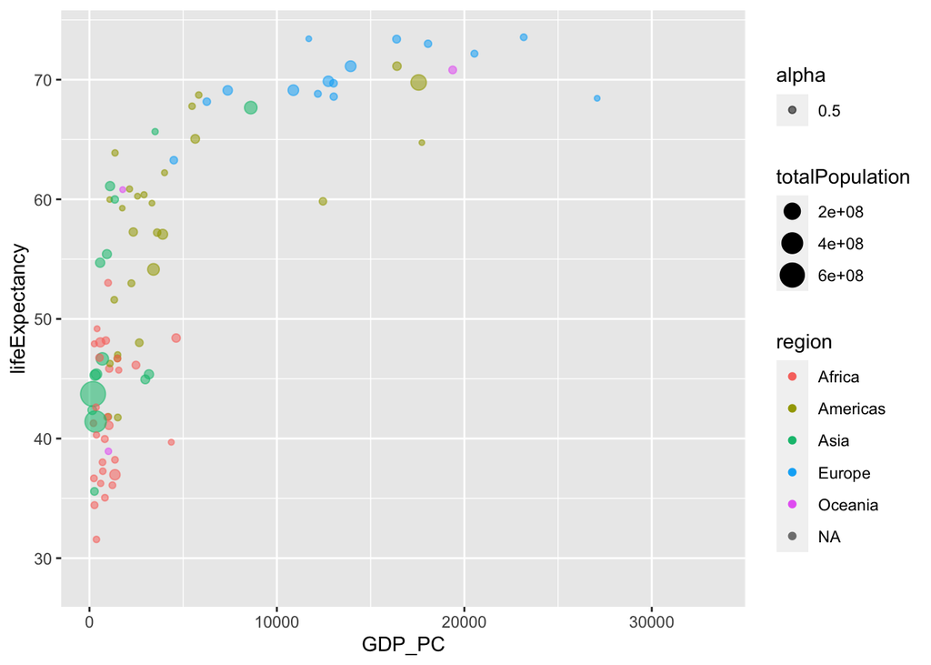

```r
gap_1960 <- gap %>%
  filter(time == "1960")
p <- ggplot(gap_1960, aes(GDP_PC, lifeExpectancy, alpha = 0.5, col=region, size=totalPopulation)) +
  geom_point()
print(p)
```

#### It seems as though there is a positive correlation between GDP per capita and life expectancy. Life expectancy increases at a high rate with an increase in GDP per capita however eventually it slows down significantly. This implies there’s a limit on how high life expectancy can increase

### 2.

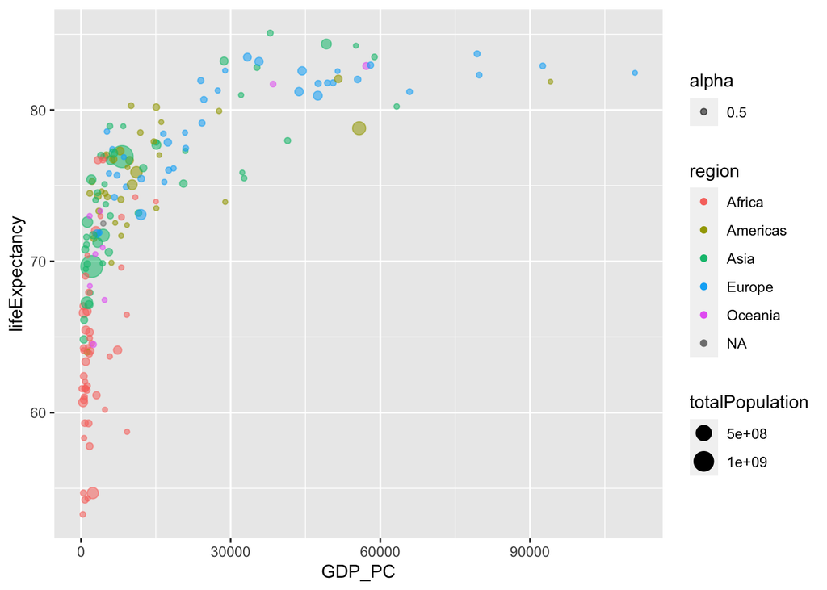

```r
gap_2019 <- gap %>%
  filter(time == 2019)
p <- ggplot(gap_2019, aes(GDP_PC, lifeExpectancy, alpha=0.5, col=region, size=totalPopulation)) +
  geom_point()
print(p)
```

```r
gap %>%
  filter(time == 1960) %>%
  group_by(region) %>%
  summarize(avg_LE <- mean(lifeExpectancy, na.rm = TRUE)) %>%
  print(avg_LE)
```

```
## Error in get_width_print(width): object 'avg_LE' not found
```

```r
gap %>%
  filter(time == 2019) %>%
  group_by(region) %>%
  summarize(avg_LE <- mean(lifeExpectancy, na.rm = TRUE)) %>%
  print(avg_LE)
```

```
## Error in get_width_print(width): object 'avg_LE' not found
```

### 5.

```r
gap %>%
  filter(time %in% c(1960, 2019)) %>%
  group_by(region) %>%
  summarize(avg_le_1960 = mean(lifeExpectancy[time == 1960], na.rm = TRUE), avg_le_2019 = mean(lifeExpectancy[time == 2019], na.rm = TRUE)) %>%
  mutate(leGrowth = ((avg_le_2019 - avg_le_1960)-1)/100) %>%
  arrange(desc(leGrowth))
```

```
## # A tibble: 6 × 4
##   region   avg_le_1960 avg_le_2019 leGrowth
##   <chr>          <dbl>       <dbl>    <dbl>
## 1 Asia            51.6        74.6   0.220
## 2 Africa          41.5        64.1   0.216
## 3 Americas        58.6        75.8   0.162
## 4 Oceania         56.4        73.5   0.161
## 5 Europe          68.3        79.4   0.101
## 6 <NA>            70.7        77.8   0.0605
```

### 6.

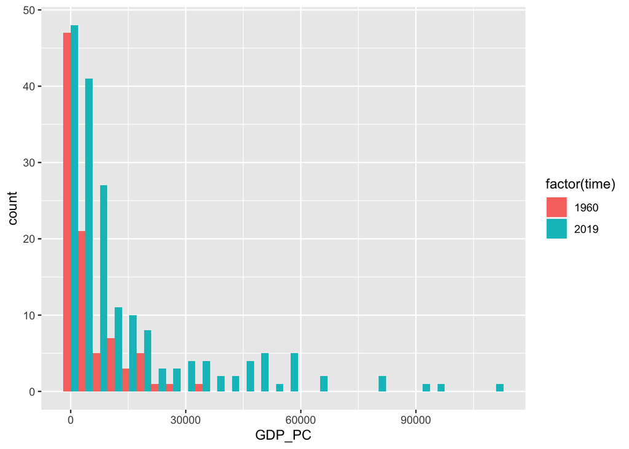

```r
gap_hist <- gap %>%
  filter(time %in% c(1960, 2019))
ggplot(gap_hist, aes(x=GDP_PC, fill = factor(time))) + geom_histogram(position="dodge")
```

### 7.

```r
gap %>%
  filter(time == 1960) %>%
  select(name, lifeExpectancy) %>%
  mutate(place = rank(-lifeExpectancy)-1) %>%
  filter(name == "United States of America") %>%
  print()
```

```
## # A tibble: 1 × 3
##   name                     lifeExpectancy place
##   <chr>                             <dbl> <dbl>
## 1 United States of America           69.8    17
```

```r
gap %>%
  filter(time == 2019) %>%
  select(name, lifeExpectancy) %>%
  mutate(place = rank(-lifeExpectancy)-1) %>%
  filter(name == "United States of America") %>%
  print()
```

```
## # A tibble: 1 × 3
##   name                     lifeExpectancy place
##   <chr>                             <dbl> <dbl>
## 1 United States of America           78.8    46
```

### 8.

```r
gap %>%
  filter(time == 1960) %>%
  filter(!is.na(lifeExpectancy)) %>%
  arrange(desc(lifeExpectancy)) %>%
  mutate(place = rank(-lifeExpectancy)-1, relative_rank=place/n()) %>%
  filter(name == "United States of America") %>%
  select(name, lifeExpectancy, relative_rank) %>%
  print()
```

```
## # A tibble: 1 × 3
##   name                     lifeExpectancy relative_rank
##   <chr>                             <dbl>         <dbl>
## 1 United States of America           69.8        0.0899
```

```r
gap %>%
  filter(time == 2019) %>%
  filter(!is.na(lifeExpectancy)) %>%
  arrange(desc(lifeExpectancy)) %>%
  mutate(place = rank(-lifeExpectancy)-1, relative_rank=place/n()) %>%
  filter(name == "United States of America") %>%
  select(name, lifeExpectancy, relative_rank) %>%
  print()
```

```
## # A tibble: 1 × 3
##   name                     lifeExpectancy relative_rank
##   <chr>                             <dbl>         <dbl>
## 1 United States of America           78.8         0.232
```

#### America still dropped in terms of relative rank from 1960 to 2019